# DraftOne

Sarah Koehler

June 1, 2016

# Methods

## Generating the simulated data

### Exposure data

There are several different possible ways to generate the simulated exposure data (or to pull in observed data to use for this).

For all of the simulated exposure series, this starts by specifying the number of days to simulate, `n`:

```r
n <- 1000
```

#### Binary exposure

For a binary exposure, then it’s necessary to specify the probability of exposure, `p_exp`. Then it’s pretty straightforward to generate the series of exposures:

```r
# Generate a binary exposure
p_exp <- 0.1
x <- sample(c(0, 1), size = n, replace = TRUE, prob = c(1-p_exp, p_exp))
head(x)
```

```
## [1] 0 0 0 0 0 0
```

Here’s a function that takes arguments of `n` and `p_exp` and returns a generated series (I’m also adding in a part to put in dates– unless I specify otherwise, this will default to start at Jan. 1, 2000):

```r
# Function to generate a binary exposure
binary_exposure
```

```
## function(n, p, start.date = "2000-01-01", ...){
##   start.date <- as.Date(start.date)
##   date <- seq(from = start.date, by = 1, length.out = n)
##   x <- sample(c(0, 1), size = n, replace = TRUE,
##               prob = c(1-p, p))
##   df <- data.frame(date, x)
##   return(df)
## }
## <environment: namespace:eesim>
```

```r
binary_exposure(n = 5, p = 0.25)
```

```
##         date x
## 1 2000-01-01 0
## 2 2000-01-02 0
## 3 2000-01-03 0
## 4 2000-01-04 0
## 5 2000-01-05 0
```

#### Continuous exposure

For a continuous exposure (which I’ll assume it’s okay to assume is normally distributed), it’s necessary to specify the mean, `mu`, and standard deviation, `sd`, of the distribution of the exposure. Then it’s possible to simulate the data:

```r
# Generate a continuous exposure
mu <- 10 # These values are both from the Chicago NMMAPS values for
sd <- 10 # temperature in degrees Celcius
x <- rnorm(n, mean = mu, sd = sd)
head(x)
```

```
## [1]  6.557323  6.135615 11.897910 16.820992 19.002003 16.204309
```

```r
# Function to generate a continuous exposure
continuous_exposure
```

```
## function(n, mu, sd, start.date = "2000-01-01", ...){
##   start.date <- as.Date(start.date)
##   date <- seq(from = start.date, by = 1, length.out = n)
##   x <- rnorm(n, mean = mu, sd = sd)
##   df <- data.frame(date, x)
##   return(df)
## }
## <environment: namespace:eesim>
```

```r
continuous_exposure(n = 5, mu = 10, sd = 10)
```

```
##         date          x
## 1 2000-01-01 24.5798596
## 2 2000-01-02 17.8449976
## 3 2000-01-03 10.8802582
## 4 2000-01-04  1.4963953
## 5 2000-01-05  0.2727985
```

#### Generate exposure data with seasonal pattern

```r
# Get Chicago NMMAPS data and use CVD
library(dlnm)
data(chicagoNMMAPS)
chic <- chicagoNMMAPS
names(chic)
```

```
##  [1] "date"  "time"  "year"  "month" "doy"   "dow"   "death" "cvd"
##  [9] "resp"  "temp"  "dptp"  "rhum"  "pm10"  "o3"
```

```r
cvd <- chic$cvd
```

#### Pull real data

```r
# Pull exposure with a seasonal pattern
library(dlnm)
data(chicagoNMMAPS)
chic <- chicagoNMMAPS

if(n < nrow(chic)){
        start <- sample(1:(nrow(chic) - n), 1) # randomly choose a starting point
        x <- chic$temp[start:(start + n -1)]
}
head(x)
```

```
## [1] 19.44444 21.66667 20.27778 18.88889 19.72222 26.38889
```

```r
# Function to pull exposure with a seasonal pattern
# Note: Your `data` must have a column called `date` as well as one with the
# measure you specify, with that column name.
pull_exposure <- function(n, data = "chicagoNMMAPS", measure = "temp", ...){
        if(data == "chicagoNMMAPS"){
                require(dlnm)
                data(chicagoNMMAPS)
                data <- chicagoNMMAPS
        }

        data$measure <- data[ , measure]

        if(n < nrow(data)){
                # randomly choose a starting point
                start <- sample(1:(nrow(data) - n), 1)
                df <- data[start:(start + n - 1), c("date", measure)]
        } else{
                stop("You asked for too many simulated observations given the dataset you're pulling the data from. Try a smaller value of n.")
        }

        return(df)
}

pull_exposure(n = 3)
```

```
##            date       temp
## 1862 1992-02-05  0.2777778
## 1863 1992-02-06  1.3888889
## 1864 1992-02-07 -2.2222222
```

```r
pull_exposure(n = 3)
```

```
##            date     temp
## 4477 1999-04-04 13.33333
## 4478 1999-04-05 10.00000
## 4479 1999-04-06 11.66667
```

```r
pull_exposure(n = 3, measure = "pm10")
```

```
##            date      pm10
## 3004 1995-03-23  7.590014
## 3005 1995-03-24 14.187432
## 3006 1995-03-25 22.124662
```

### Expected values for outcome data

#### Constant baseline hazard rate

To generate the expected mean baseline for an outcome with a constant baseline hazard rate over time, you just need to specify the $\lambda$ value for the distribution of the outcome (if you’re using a Poisson distribution):

```r
# Contant baseline of outcome
lambda <- 100 # Approximate mean value of daily deaths for chicagoNMMAPS
exp_base_y <- rep(lambda, n)
```

```r
constant_baseline <- function(n, lambda, start.date = "2000-01-01", ...){
        start.date <- as.Date(start.date)
        date <- seq(from = start.date, by = 1, length.out = n)
        exp_base_y <- rep(lambda, n)
        df <- data.frame(date = date,
                         exp_base_y = exp_base_y)
        return(df)
}
constant_baseline(n = 3, lambda = 100)
```

```
##         date exp_base_y
## 1 2000-01-01        100
## 2 2000-01-02        100
## 3 2000-01-03        100
```

#### Baseline hazard rate varies by season

```r
calc_t
```

```
## function(n, trend = "no trend"){
##   day <- c(1:n)
##   if (trend == "cos1"){
##     seasont <- 1 + .6 * cos(2 * pi * (day / 365))
##     } else if (trend == "cos2"){
##     seasont <- 1 + .6 * cos(2 * pi * (day / 365)) +
##       ifelse(day < 639 & day > 274, .4 * cos(2 * (pi * (day / 365))), 0)
##     } else if (trend == "cos3"){
##       seasont <- 1 + .75 ^ (day / 365) * .6 * cos(2 * pi * (day / 365))
##     } else if (trend == "linear"){
##       seasont <- 1 + (day / n)
##     } else if (trend == "curvilinear"){
##       seasont <- 1+ day * (2 / n) + day^2 * (-1 / n^2)
##     } else if (trend == "cos1linear"){
##       seasont <- (1 + (day / n)) * (1 + .6 * cos(2 * pi * (day / 365)))
##     } else if (trend == "no trend"){
##       seasont <- 1
##     } else{
##       stop(paste0("`trend` value is not a valid choice. Please check the",
##                   " function documentation to select a valid option."))
##     }
##   return(seasont)
## }
## <environment: namespace:eesim>
```

We need to generate the explanatory exposure variable. Here are functions for binary and continuous exposure which varies by season.

```r
# A function for binary exposure which varies by season:
season_binexp
```

```
## function(n, p, start.date = "2000-01-01", ...){
##   start.date <- as.Date(start.date)
##   date <- seq(from = start.date, by = 1, length.out = n)
##   p <- p #Change this later to reflect probability varying by season using trends
##   x <- sample(c(0, 1), size = n, replace = T, prob = c(1 - p, p))
##   df <- data.frame(date, x)
##   return(df)
## }
## <environment: namespace:eesim>
```

```r
# A function for continuous exposure which varies by season:
season_contexp
```

```
## function(n, mu, sd, trend, start.date = "2000-01-01", ...){
##   day <- c(1:n)
##   t <- calc_t(n, trend)
##   start.date <- as.Date(start.date)
##   date <- seq(from = start.date, by = 1, length.out = n)
##   mu <- mu * t
##   x <- rnorm(n, mean = mu, sd = sd)
##   df <- data.frame(date, x)
##   return(df)
## }
## <environment: namespace:eesim>
```

```r
#Seasonal baseline
seasonal_baseline <- function(n, lambda, trend, start.date="2000-01-01", ...){
  start.date <- as.Date(start.date)
  date <- seq(from = start.date, by=1, length.out=n)
  t <- calc_t(n=n, ...)
  exp_base_y <- lambda*t
  df <- data.frame(date=date, exp_base_y=exp_base_y)
  return(df)
}
```

Here’s a plot of the trends:

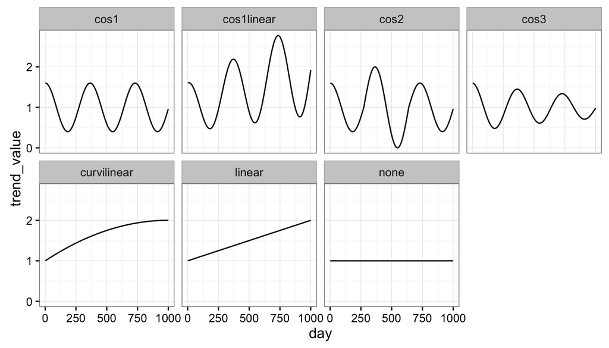

```r
library(dplyr)
library(tidyr)
library(ggplot2)

data.frame(day = 1:1000) %>%
  mutate(none = calc_t(n = 1000, trend = "no trend"),
         cos1 = calc_t(n = 1000, trend = "cos1"),
         cos2 = calc_t(n = 1000, trend = "cos2"),
         cos3 = calc_t(n = 1000, trend = "cos3"),
         linear = calc_t(n = 1000, trend = "linear"),
         curvilinear = calc_t(n = 1000, trend = "curvilinear"),
         cos1linear = calc_t(n = 1000, trend = "cos1linear")) %>%
  gather(trend_method, trend_value, -day) %>%
  ggplot(aes(x = day, y = trend_value)) +
  geom_line() + facet_wrap(~ trend_method, ncol = 4) +
  theme_bw()
```

Next, a function to simulate the outcomes.

```r
#Here, exposure would be the output from the season_binexp function and t would be the output from the calc_t function.
sim_binout <- function(n, mean_out, t, exposure, rr){
  day <- c(1:n)
  rr <- ifelse(exposure == 1, rr, 1)
  exp_base_y <- mean_out*t
  exp_y <- mean_out*t*rr
  y <- rpois(n, exp_y)
  df <- data.frame(exp_base_y=exp_base_y, exp_y=exp_y, y=y)
  return(df)
}

#Here, exposure would be the output from the season_contexp function and t is from calc_t.
sim_contout<- function(n, mu, t, exposure, rr){
  day <- c(1:n)
  exp_y <- mu*t*rr*(exposure/sd(exposure))
  y <- rpois(n, exp_y)
  df <- data.frame( exp_y=exp_y, y=y)
  return(df)
}
```

```r
#Put "date" in the data frame like the others?
sim_seasdata <- function(n, rr, trend, x_type="binary", p, mu, sd, mean_out){
  if(x_type == "binary"){
    x <- season_binexp(n, p)
    t <- calc_t(n, trend)
    simdata <- data.frame(x, sim_binout(n, mean_out, t, x, rr))
  }
  else if(x_type == "continuous"){
    x <- season_contexp(n, mu, sd, trend)
    t <- calc_t(n, trend)
    simdata <- sim_contout(n, mu, t, x, rr)
  }
 return(simdata)
}
```

Here are some examples of this function:

```r
sim_seasdata(n = 3, rr = 1.2, trend="cos2", x_type="binary", p=.2, mean_out = 100)
```

```
##         date x exp_base_y exp_y.date  exp_y.x   y
## 1 2000-01-01 0   159.9911   159.9911 159.9911 140
## 2 2000-01-02 0   159.9644   159.9644 159.9644 162
## 3 2000-01-03 0   159.9200   159.9200 159.9200 167
```

```r
# Outcome with mortality displacement

# Outcome with delayed, slightly elevated risk
```

### Simulated outcome data

Moving from the expected value of the baseline outcome to simulated outcome data requires a few things. First, it’s necessary to specify the true effect associated with the exposure:

```r
# Specify true effect
rr <- 1.2
```

Then, it’s necessary to combine the exposure, `x`, and expected baseline outcome values, `exp_base_y`, in a dataframe:

```r
n <- 1000
p <- 0.25
lambda <- 100

x <- binary_exposure(n = n, p = p)
exp_base_y <- constant_baseline(n = n, lambda = lambda)
df <- full_join(x, exp_base_y, by = "date")
```

Then you can generate the `exp_y` using the equation:

$$E(log(\mu_t)) = \beta_0 + \beta_1X_1$$

(For this, it will be important that the relative risk is specified for a **one-unit** increase in the exposure value.)

```r
df <- mutate(df, exp_y = exp(log(exp_base_y) + log(rr) * x))
```

Now, you need to decide on how the outcome data is distributed around the expected value. This is simulating outcome values from a Poisson distribution using `rpois`.

```r
# Simulate outcome data
df$y <- sapply(df$exp_y, FUN = function(x) rpois(1, x))
head(df, 3)
```

```
##         date x exp_base_y exp_y   y
## 1 2000-01-01 0        100   100 112
## 2 2000-01-02 0        100   100  99
## 3 2000-01-03 0        100   100  89
```

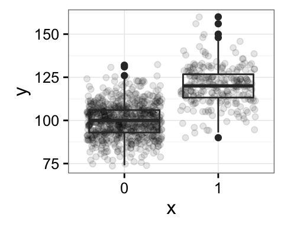

```r
to_plot <- mutate(df, x = as.factor(x))
ggplot(to_plot, aes(x = x, y = y)) +
        geom_point(position = position_jitter(), alpha = 0.1) +
        geom_boxplot( fill = NA) +
        theme_bw()
```

```r
group_by(df, exp_y) %>% summarize(mean_y = mean(y))
```

```
## Source: local data frame [2 x 2]
##
##   exp_y    mean_y
##   (dbl)     (dbl)
## 1   100  99.86595
## 2   120 120.01181
```

Here is a function to do all this:

```r
sim_data
```

```
## function(n, rr, lambda, x_type = "binary", trend = "constant",
##                      start.date = "2000-01-01", ...){
##
##   require(dplyr)
##
##   if(trend=="constant"){
##     if(x_type == "binary"){
##       x <- binary_exposure(n=n, ...)
##     }
##     else if(x_type == "continuous"){
##       x <- continuous_exposure(n=n, ...)
##     }
##     exp_base_y <- constant_baseline(n=n, lambda = lambda, start.date = start.date)
##     df <- full_join(x, exp_base_y, by="date") %>% mutate(exp_y =
##                                                            exp(log(exp_base_y)+log(rr)*x))
##     df$y <- sapply(df$exp_y, FUN = function(x) rpois(1,x))
##   }
##
##   else if(trend != "constant"){
##     if(x_type == "binary"){
##       x <- season_binexp(n = n, ...)
##     }
##     else if(x_type == "continuous"){
##       x <- season_contexp(n = n, trend = trend, ...)
##     }
##     exp_base_y <- seasonal_baseline(n = n, lambda = lambda, start.date = start.date,
##                                     trend = trend)
##     df <- full_join(x, exp_base_y, by="date") %>% mutate(exp_y =
##                                                            exp(log(exp_base_y)+log(rr)*x))
##     df$y <- sapply(df$exp_y, FUN = function(x) rpois(1,x))
##   }
##   return(df)
## }
## <environment: namespace:eesim>
```

Here are some examples of this function:

```r
sim_data(n = 3, rr = 1.2, p = .2, lambda = 100)
```

```
##         date x exp_base_y exp_y   y
## 1 2000-01-01 0        100   100 103
## 2 2000-01-02 1        100   120 125
## 3 2000-01-03 0        100   100  98
```

```r
sim_data(n = 3, rr = 1.02, x_type = "continuous", mu = 10, sd = 10,
         lambda = 100)
```

```
##         date        x exp_base_y    exp_y   y
## 1 2000-01-01 26.63010        100 169.4429 167
## 2 2000-01-02 20.56596        100 150.2695 144
## 3 2000-01-03 13.72707        100 131.2366 130
```

## Fitting the models

### Generalized linear model

The formula for the generalized linear model (GLM) is:

$$E(log(\mu_t)) = \beta_0 + \beta_1X_t + \mbox{ns(time, d.f.)}$$

where:

- $\mu_t$: Count of outcomes on day $t$, dispersed as a quasi-Poisson distribution
- $\beta_0$: Intercept (expected log count of health outcome when $X_t$ equals 0 and for middle of the timeframe [so `time` = 0])
- $\beta_1$: log relative risk for a 1-unit increase in exposure $X_t$
- $X_t$: Exposure on day $t$
- $\mbox{ns(time, d.f.)}$: Spline of time for $\mbox{d.f.}$ degrees of freedom per year

```r
# Fit a generalized linear model
spline_mod
```

```
## function(df, df_year = 7){
##   dgrs_free <- df_year * as.numeric(diff(df[c(1, nrow(df)), "date"])) / 365.4
##   df$time <- scale(df$date, center = TRUE, scale = FALSE)
##   mod <- glm(y ~ x + ns(time, round(dgrs_free)),
##              data = df,
##              family = quasipoisson(link = "log"))
##
##   out_1 <- summary(mod)$coef[2, ]
##   out_2 <- confint.default(mod)[2, ]
##   out <- c(out_1, out_2)
##   return(out)
## }
## <environment: namespace:eesim>
```

Here are some examples of fitting this model:

```r
df <- sim_data(n = 5 * 365, rr = 1.2, p = .2, lambda = 100)
spline_mod(df)
```

```
##      Estimate    Std. Error       t value      Pr(>|t|)         2.5 %
##  1.815617e-01  5.721638e-03  3.173248e+01 1.135253e-175  1.703475e-01
##        97.5 %
##  1.927759e-01
```

```r
exp(spline_mod(df)[1])
```

```
## Estimate
## 1.199089
```

```r
df <- sim_data(n = 5 * 365, rr = 1.02, x_type = "continuous",
               mu = 10, sd = 10, lambda = 100)
spline_mod(df)
```

```
##     Estimate   Std. Error      t value     Pr(>|t|)        2.5 %
## 1.950521e-02 2.137327e-04 9.125981e+01 0.000000e+00 1.908630e-02
##       97.5 %
## 1.992411e-02
```

```r
exp(spline_mod(df)[1])
```

```
## Estimate
## 1.019697
```

### Case-crossover model

Here is the formula for the case-crossover model. It’s actually using a quasi-Poisson GLM with a factor included identifying stratum (month and year):

$$E(log(\mu_t)) = \beta_0 + \beta_1X_t + \beta_2S_t$$

where:

- $\mu_t$: Count of outcomes on day $t$, assuming these outcomes follow a quasi-Poisson distribution
- $\beta_0$: Intercept (expected log count of health outcome when $X_t$ equals 0 and for the baseline level of the time strata
- $\beta_1$: log relative risk for a 1-unit increase in exposure $X_t$
- $X_t$: Exposure on day $t$
- $\beta_2$: offset for log baseline counts for each stratum
- $S_t$: Time stratum (month and year)

```r
# Fit a case-crossover model
casecross_mod
```

```
## function(df){
##   df$stratum <- factor(format(df$date, "%Y.%m"))
##
##   if (sum(df$x == 0 | df$x == 1) == length(df$x)){
##     event.check <- as.matrix(table(df$stratum, df$x))
##     informative.strata <- rownames(event.check)[apply(event.check,
##                                                       1, prod) > 0]
##     df <- subset(df, stratum %in% informative.strata)
##
##     if(length(informative.strata) > 1){
##       mod <- glm(y ~ x + stratum,
##                  data = df,
##                  family = quasipoisson(link = "log"))
##     } else {
##       mod <- glm(y ~ x,
##                  data = df,
##                  family = quasipoisson(link = "log"))
##     }
##   } else {
##     mod <- glm(y ~ x + stratum,
##                data = df,
##                family = quasipoisson(link = "log"))
##   }
##
##   out_1 <- summary(mod)$coef[2, ]
##   out_2 <- confint.default(mod)[2, ]
##   out <- c(out_1, out_2)
##   return(out)
## }
## <environment: namespace:eesim>
```

Here are some examples of fitting this model:

```r
df <- sim_data(n = 5 * 365, rr = 1.2, p = .2, lambda = 100)
casecross_mod(df)
```

```
##      Estimate    Std. Error       t value      Pr(>|t|)         2.5 %
##  1.782652e-01  5.700336e-03  3.127275e+01 3.470555e-171  1.670927e-01
##        97.5 %
##  1.894376e-01
```

```r
exp(casecross_mod(df)[1])
```

```
## Estimate
## 1.195142
```

```r
df <- sim_data(n = 5 * 365, rr = 1.02, x_type = "continuous",
               mu = 10, sd = 10, lambda = 100)
casecross_mod(df)
```

```
##     Estimate   Std. Error      t value     Pr(>|t|)        2.5 %
## 1.993385e-02 2.271598e-04 8.775253e+01 0.000000e+00 1.948863e-02
##       97.5 %
## 2.037908e-02
```

```r
exp(casecross_mod(df)[1])
```

```
## Estimate
## 1.020134
```

### Cross-year model

$$E(log(\mu_t)) = \beta_0 + \beta_1X_t + \beta_2D_t + \beta_3Y_t$$

```r
# Fit a cross-year model
crossyear_mod
```

```
## function(df){
##   df$stratum <- factor(format(df$date, "%j"))
##   df$year <- factor(format(df$date, "%Y"))
##
##   if (sum(df$x == 0 | df$x == 1) == length(df$x)){
##     event.check <- as.matrix(table(df$stratum, df$x))
##     informative.strata <- rownames(event.check)[apply(event.check,
##                                                       1, prod) > 0]
##     df <- subset(df, stratum %in% informative.strata)
##
##     if(length(informative.strata) > 1){
##       mod <- glm(y ~ x + stratum,
##                  data = df,
##                  family = quasipoisson(link = "log"))
##     } else {
##       mod <- glm(y ~ x,
##                  data = df,
##                  family = quasipoisson(link = "log"))
##     }
##   } else {
##     mod <- glm(y ~ x + stratum,
##                data = df,
##                family = quasipoisson(link = "log"))
##   }
##
##   out_1 <- summary(mod)$coef[2, ]
##   out_2 <- confint.default(mod)[2, ]
##   out <- c(out_1, out_2)
##   return(out)
## }
## <environment: namespace:eesim>
```

Here are some examples of applying this model:

```r
df <- sim_data(n = 5 * 365, rr = 1.2, p = .2, lambda = 100)
crossyear_mod(df)
```

```
##      Estimate    Std. Error       t value      Pr(>|t|)         2.5 %
##  1.936854e-01  6.346398e-03  3.051895e+01 2.514020e-143  1.812467e-01
##        97.5 %
##  2.061241e-01
```

```r
exp(crossyear_mod(df)[1])
```

```
## Estimate
## 1.213714
```

```r
df <- sim_data(n = 5 * 365, rr = 1.02, x_type = "continuous",
               mu = 10, sd = 10, lambda = 100)
crossyear_mod(df)
```

```
##     Estimate   Std. Error      t value     Pr(>|t|)        2.5 %
##  0.019649344  0.000224482 87.531931999  0.000000000  0.019209367
##       97.5 %
##  0.020089320
```

```r
exp(crossyear_mod(df)[1])
```

```
## Estimate
## 1.019844
```

## Run lots of simulations

Now it’s pretty easy to run lots of simulations using `replicate`:

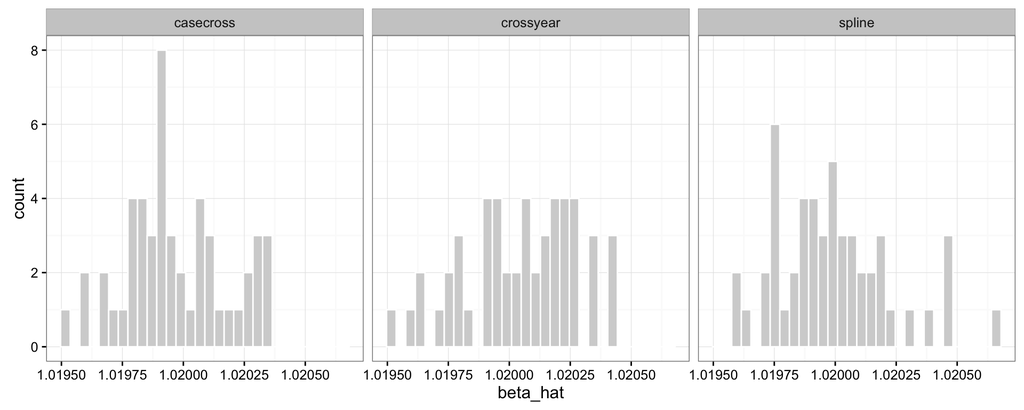

```r
n_sim <- 50
ex_spline <- replicate(n_sim, exp(spline_mod(sim_data(n = 5 * 365,
                                          rr = 1.02, x_type = "continuous",
                                          mu = 10, sd = 10, lambda = 100))[1]))

ex_casecross <- replicate(n_sim, exp(casecross_mod(sim_data(n = 5 * 365,
                                          rr = 1.02, x_type = "continuous",
                                          mu = 10, sd = 10, lambda = 100))[1]))

ex_crossyear <- replicate(n_sim, exp(crossyear_mod(sim_data(n = 5 * 365,
                                          rr = 1.02, x_type = "continuous",
                                          mu = 10, sd = 10, lambda = 100))[1]))

ex <- data.frame(beta_hat = c(ex_spline, ex_casecross, ex_crossyear),
                 model = rep(c("spline", "casecross", "crossyear"),
                             each = n_sim)) %>%
        mutate(model = factor(model))

ggplot(ex, aes(x = beta_hat)) +
        geom_histogram(fill = "lightgray", color = "white") +
        facet_wrap(~ model, ncol = 3) +
        theme_bw()
```

```r
group_by(ex, model) %>%
        summarize(mean_beta = mean(beta_hat), sd_beta = sd(beta_hat))
```

```
## Source: local data frame [3 x 3]
##
##       model mean_beta      sd_beta
##      (fctr)     (dbl)        (dbl)
## 1 casecross  1.019969 0.0002117997
## 2 crossyear  1.020047 0.0002270228
## 3    spline  1.019989 0.0002378730
```

Here is a function that will run a lot of simulations for a given dataset and model and will output a dataframe with the $\hat{\beta}$, $sd(\hat\beta)$, and p-values for the $\beta$ for each replication:

```r
rep_sims
```

```
## function(n_sims, model, n = 5 * 365, rr = 1.01,
##                      x_type = "continuous", mu = 10, sd = 2, lambda = 100){
##   out <- replicate(n_sims, eval(call(model,
##                                      sim_data(n = n, rr = rr,
##                                               x_type = x_type,
##                                               mu = mu, sd = sd,
##                                               lambda = lambda))))
##   out <- as.data.frame(t(out))
##   names(out) <- c("est", "se", "t", "p", "lower_ci", "upper_ci")
##   return(out)
## }
## <environment: namespace:eesim>
```

Here are some examples of using this function:

```r
rep_sims(n_sims = 3, model = "spline_mod")
```

```
##           est          se        t            p    lower_ci   upper_ci
## 1 0.010175856 0.001124491 9.049299 3.654966e-19 0.007971894 0.01237982
## 2 0.008722107 0.001130206 7.717274 1.962253e-14 0.006506945 0.01093727
## 3 0.009817263 0.001139802 8.613131 1.533992e-17 0.007583292 0.01205123
```

```r
rep_sims(n_sims = 3, model = "casecross_mod")
```

```
##          est          se        t            p    lower_ci   upper_ci
## 1 0.01041079 0.001090027 9.550950 4.121013e-21 0.008274381 0.01254721
## 2 0.01040101 0.001150075 9.043762 3.883899e-19 0.008146899 0.01265511
## 3 0.01036946 0.001155853 8.971267 7.305483e-19 0.008104034 0.01263489
```

```r
rep_sims(n_sims = 3, model = "crossyear_mod")
```

```
##           est          se        t            p    lower_ci   upper_ci
## 1 0.009702409 0.001182746 8.203291 5.080973e-16 0.007384270 0.01202055
## 2 0.009245988 0.001221809 7.567460 6.710589e-14 0.006851287 0.01164069
## 3 0.010549009 0.001272079 8.292731 2.485859e-16 0.008055780 0.01304224
```

## Assess performance based on simulations

All of these functions will take, as input, a dataframe of replicated simulations:

```r
rep_df <- rep_sims(n_sims = 50, model = "spline_mod", rr = 1.02)
head(rep_df, 4)
```

```
##          est          se        t            p   lower_ci   upper_ci
## 1 0.01930252 0.001049824 18.38643 2.738924e-69 0.01724491 0.02136014
## 2 0.02010853 0.001069665 18.79890 4.351525e-72 0.01801202 0.02220503
## 3 0.02157681 0.001091697 19.76446 8.464999e-79 0.01943712 0.02371649
## 4 0.01999889 0.001067417 18.73579 1.173826e-71 0.01790680 0.02209099
```

### Average estimate coefficient

This is the mean value of all the $\hat{\beta}$s over $n$ simulations [@figueiras2005analysis]. I’m also having this function calculate the mean of the $\hat{RR}$ values calculated by all the simulations.

```r
# Measure mean of estimated coefficient
mean_beta
```

```
## function(df){
##   beta_hat <- mean(df$est)
##   rr_hat <- mean(exp(df$est))
##   out <- data.frame(beta_hat, rr_hat)
##   return(out)
## }
## <environment: namespace:eesim>
```

```r
mean_beta(rep_df)
```

```
##     beta_hat  rr_hat
## 1 0.01965546 1.01985
```

### Standard deviation of estimated coefficients

This is the standard deviation of all the $\hat{\beta}$s over $n$ simulations [@figueiras2005analysis]. (In other words, I think they took all the $\hat\beta$s and took the standard deviation of all those point estimates.)

Bateson and Schwartz measure the *variance* of the estimated coefficients, instead, and they took the mean value of the variance of each of the estimated coefficients (rather than the variance across all the point estimates) [-@bateson1999control]. In other words, I think they measured:

$$\mbox{Variance} = E(Var(\hat\beta))$$

I’ll write a function that will estimate both, `var_across_betas` to correspond with Figueiras and `mean_beta_var` to correspond with Bateson and Schwartz:

```r
# Measure standard deviation across estimated coefficient
beta_var
```

```
## function(df){
##   var_across_betas <- var(df$est)
##   mean_beta_var <- mean(df$se^2)
##   out <- data.frame(var_across_betas, mean_beta_var)
##   return(out)
## }
## <environment: namespace:eesim>
```

```r
beta_var(rep_df)
```

```
##   var_across_betas mean_beta_var
## 1     8.718062e-07  1.135468e-06
```

### % bias in estimated coefficient

Based on Figueiras and coauthors, this is measured as [-@figueiras2005analysis]:

$$\mbox{% bias} = 100 \frac{(\hat{\beta} - \beta)}{\beta}$$

where $\hat{\beta}$ is the mean estimated coefficient (e.g., log relative risk) over $n$ simulations.

Wang and co-authors measure *relative bias* instead [-@wang2011potential]:

$$\mbox{% bias} = 100 \frac{(\beta - \hat{\beta})}{\beta}$$

I’ll write a function that measures both (`fig_bias` and `wang_bias`):

```r
# Measure percent bias
beta_bias <- function(df, true_rr){
        fig_bias <- 100 * (mean(df$est) - true_rr) / true_rr
        wang_bias <- 100 * (true_rr - mean(df$est)) / true_rr
        out <- data.frame(fig_bias, wang_bias)
        return(out)
}
beta_bias(rep_df, true_rr = 1.02)
```

```
##    fig_bias wang_bias
## 1 -98.07299  98.07299
```

As a note, one of these will just be the negative of the other… Does it make more sense to just take the absolute value of the difference between the two estimates and divide it by $\beta$?

### % coverage of estimated coefficients

$$\mbox{% coverage} = \mbox{% of simulations with 95% CIs that cover }\beta$$

where $\beta$ is the true value of the coefficient (e.g., log relative risk) [@figueiras2005analysis].

From Butland and coauthors [@butland2013measurement]:

> “An estimate of coverage probability records the percentage of simulations where the 95% confidence interval contains the ‘true’ value of $\beta$.”

From Bateson and Schwartz [@bateson1999control]:

> “Coverage probabilities are the percentages of the 1,000 confidence intervals that included the true relative risk of exposure.”

These all seem to be saying the same thing.

```r
# Measure coverage
coverage_beta <- function(df, true_rr){
        true_beta <- log(true_rr)
        coverage <- df$lower_ci <= true_beta & df$upper_ci >= true_beta
        out <- data.frame(coverage = sum(coverage) / nrow(df))
        return(out)
}

coverage_beta(rep_df, true_rr = 1.02)
```

```
##   coverage
## 1     0.98
```

### Power

This is the percent of all estimated coefficients for the $n$ simulations where the lower 95% confidence interval is above 0 [@figueiras2005analysis]. This is a metric of statistical efficiency.

From Butland and coauthors [@butland2013measurement]:

> “An estimate of power records the percentage of simulations that would have detected the health effect estimate as statistically significant at the 5% significance level.”

These also seem to be saying the same thing.

```r
# Measure power
power_beta <- function(df){
        no_zero <- df$lower_ci >= 0 | df$upper_ci <= 0
        out <- data.frame(power = sum(no_zero) / nrow(df))
        return(out)
}

power_beta(rep_df)
```

```
##   power
## 1     1
```

### Relative efficiency

From Bateson and Schwartz [@bateson1999control]:

> “Relative efficiency is the ratio of the $V_{Poi}$ to the $V_{SBI}$.”

Where $V_{Poi}$ is the means of 1,000 parameter variances from the regressions of simulated values and $V_{SBI}$ is the means of 1,000 parameter variances from a case-crossover model.

This looks like it is a comparative metric. I have already measured the mean variance of the $\hat{\beta}$s with the `beta_var` function I defined above.

### Combined function to assess performance

I created a function that will perform all these checks:

```r
check_sims <- function(df, true_rr){
        a <- mean_beta(df)
        b <- beta_var(df)
        c <- beta_bias(df, true_rr = true_rr)
        d <- coverage_beta(df, true_rr = true_rr)
        e <- power_beta(df)

        out <- cbind(a, b, c, d, e)
        return(out)
}
check_sims(rep_df, true_rr = 1.02)
```

```
##     beta_hat  rr_hat var_across_betas mean_beta_var  fig_bias wang_bias
## 1 0.01965546 1.01985     8.718062e-07  1.135468e-06 -98.07299  98.07299
##   coverage power
## 1     0.98     1
```

## Power calculations

Power can vary with the following elements of the analysis:

- Size of the dataset
- Effect size
- Baseline mortality rate (here, $\lambda$)
- Patterns in exposure (variance for continuous exposure, percent of exposed days for binary exposure)

```r
power_calc <- function(varying, values, plot = FALSE, ...){
        out <- data.frame(x = values, power = NA)
        if(varying == "n"){
                for(i in 1:nrow(out)){
                        rep_df <- rep_sims(n = out$x[i], ...)
                        out$power[i] <- power_beta(rep_df)[1,1]
                }
        } else if(varying == "rr"){
                for(i in 1:nrow(out)){
                        rep_df <- rep_sims(rr = out$x[i], ...)
                        out$power[i] <- power_beta(rep_df)[1,1]
                }
        } else if(varying == "lambda"){
                for(i in 1:nrow(out)){
                        rep_df <- rep_sims(lambda = out$x[i], ...)
                        out$power[i] <- power_beta(rep_df)[1,1]
                }
        }

        if(plot == TRUE){
                        library(ggplot2)
                        my_plot <- ggplot(out, aes(x = x, y = power)) +
                                geom_line() + theme_minimal() +
                                xlab(varying)
                        print(my_plot)
        }

        colnames(out)[1] <- varying
        return(out)
}
```

Here are some examples of varying the sample size, `n`:

```r
power_calc(varying = "n", values = c(50 * (1:5)),
           n_sims = 50, model = "spline_mod", rr = 1.02)
```

```
##     n power
## 1  50  0.86
## 2 100  1.00
## 3 150  1.00
## 4 200  1.00
## 5 250  1.00
```

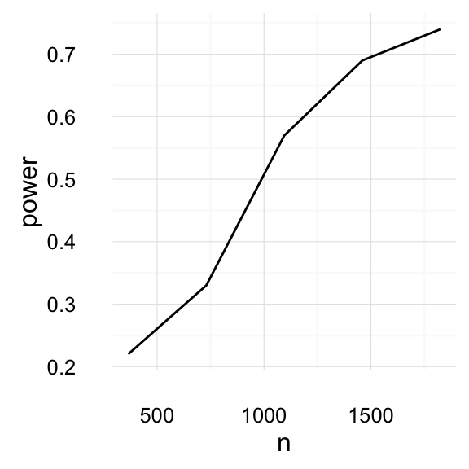

```
##      n power
## 1  365  0.22
## 2  730  0.33
## 3 1095  0.57
## 4 1460  0.69
## 5 1825  0.74
```

```r
power_calc(varying = "n", values = c(365 * (1:5)),
           n_sims = 100, model = "spline_mod", rr = 1.003, plot = TRUE)
```

Here are some examples of varying the relative risk, `r`:

```r
power_calc(varying = "rr", values = c(1.002, 1.005, 1.01, 1.02, 1.03, 1.05, 1.1),
           n_sims = 50, model = "spline_mod", n = 365 * 5)
```

```
##      rr power
## 1 1.002  0.42
## 2 1.005  1.00
## 3 1.010  1.00
## 4 1.020  1.00
## 5 1.030  1.00
## 6 1.050  1.00
## 7 1.100  1.00
```

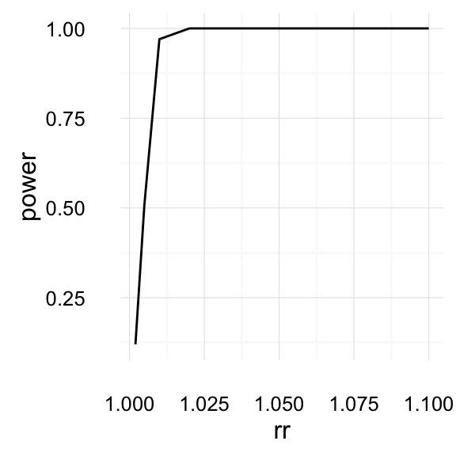

```
##      rr power
## 1 1.002  0.12
## 2 1.005  0.51
## 3 1.010  0.97
## 4 1.020  1.00
## 5 1.030  1.00
## 6 1.050  1.00
## 7 1.100  1.00
```

```r
power_calc(varying = "rr", values = c(1.002, 1.005, 1.01, 1.02, 1.03, 1.05, 1.1),
           n_sims = 100, model = "spline_mod", n = 365, plot = TRUE)
```

Here are some examples of varying the baseline mortality rate, `lambda`:

```r
power_calc(varying = "lambda", values = c(1, 5, 10, 25, 50, 75, 100),
           n_sims = 50, model = "spline_mod", n = 365 * 5, rr = 1.02)
```

```
##   lambda power
## 1      1  0.34
## 2      5  0.98
## 3     10  1.00
## 4     25  1.00
## 5     50  1.00
## 6     75  1.00
## 7    100  1.00
```

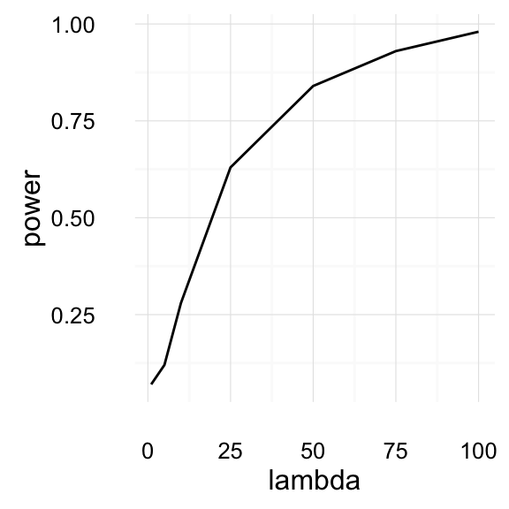

```
##   lambda power
## 1      1  0.07
## 2      5  0.12
## 3     10  0.28
## 4     25  0.63
## 5     50  0.84
## 6     75  0.93
## 7    100  0.98
```

```r
power_calc(varying = "lambda", values = c(1, 5, 10, 25, 50, 75, 100),
           n_sims = 100, model = "spline_mod", n = 365 * 5, rr = 1.005, plot = TRUE)
```

I can compare power from different models using the same data parameters (i.e., sample size, relative risk, etc.) for these:

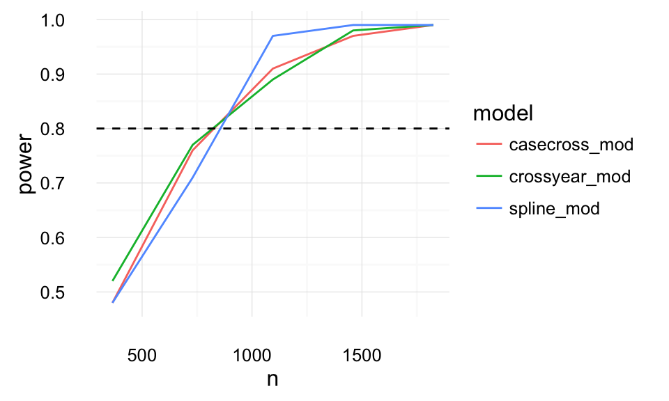

```r
for(model in c("spline_mod", "casecross_mod", "crossyear_mod")){
        df_mod <- power_calc(varying = "n", values = c(365 * (1:5)),
                             n_sims = 100, model = "spline_mod", rr = 1.005)
        df_mod$model <- model
        if(model == "spline_mod"){
                df <- df_mod
        } else {
                df <- rbind(df, df_mod)
        }
}
df$model <- factor(df$model)

ggplot(df, aes(x = n, y = power, color = model)) +
        geom_line() +
        theme_minimal() +
        geom_hline(aes(yintercept = 0.8), linetype = 2)
```